# ISL: Chapter 3

### Question 1

The null hypotheses are that each of the coefficients individually has no effect on sales in the presence of the others. One can conclude from their values that the coefficients for `Intercept`, `TV`, and `radio` are statistically different from zero while the coefficient for `newspaper` is not.

### Question 2

The KNN classifier and the KNN regression method both rely on the K nearest neighbors of a set of given predictors. However, the former predicts a qualitative outcome $Y_i$ while the latter predicts a quantative outcome $f(X_i)$.

### Question 3

We have the following model:
$$Salary = 50 + 20 \cdot GPA + 0.7 \cdot IQ + 35 \cdot I_{Female} + 0.01 \cdot GPA \times IQ - 10 \cdot GPA \times I_{Female}$$

#### (a)

For a fixed value of $IQ$ and $GPA$, males earn more on average than females provided that $GPA$ is high enough.

#### (c)

False, we need to know the p-value to have supporting evidence. Furthermore, the effect of the interaction term will depend on the scale of the $IQ$ and $GPA$ variables.

### Question 4

Comparing linear and cubic regressions given a linear DGP:

#### (a)

We would expect the training RSS to be lower using the cubic regression since it is more flexible.

#### (b)

We would expect the test RSS to be higher using the cubic regression due to overfitting.

#### (c)

The cubic regression will always perform better (in terms of training RSS).

#### (d)

Given a non-linear DGP, there is not enough information to know since the relationship may be close to linear or highly non-linear.

### Question 5

Substitution and rearranging implies:
$$\hat y_i = x_i \frac{\sum_{j=1}^n x_j y_j}{\sum_{k=1}^n x_k^2} = \sum_{j=1}^n \frac{x_i x_j}{\sum_{k=1}^n x_k^2} y_j = \sum_{j=1}^n a_j y_j$$
where
$$a_j = \frac{x_i x_j}{\sum_{k=1}^n x_k^2}$$

### Question 6

The regression line is given by:
$$y = \beta_0 + \beta_1 x$$
Substituting in the fact that $\beta_0 = \bar y - \beta_1 \bar x$ implies:
$$y = \bar y - \beta_1 \bar x + \beta_1 x$$
Plugging in the point $(\bar x, \bar y)$ implies:
$$\bar y = \bar y - \beta_1 \bar x + \beta_1 \bar x$$
which obviously holds.

### Question 7

Skip

### Question 8

#### (a)

```r
library(MASS)

lm08 <- lm(mpg ~ horsepower, data = Auto)
summary(lm08)
```

```
##
## Call:
## lm(formula = mpg ~ horsepower, data = Auto)
##
## Residuals:
##     Min      1Q  Median      3Q     Max
## -13.571  -3.259  -0.344   2.763  16.924
##
## Coefficients:
##             Estimate Std. Error t value Pr(>|t|)
## (Intercept) 39.93586    0.71750    55.7   <2e-16 ***
## horsepower  -0.15784    0.00645   -24.5   <2e-16 ***
## ---
## Signif. codes:  0 '***' 0.001 '**' 0.01 '*' 0.05 '.' 0.1 ' ' 1
##
## Residual standard error: 4.91 on 390 degrees of freedom
## Multiple R-squared:  0.606,  Adjusted R-squared:  0.605
## F-statistic:  600 on 1 and 390 DF,  p-value: <2e-16
```

The F-statistic indicates there is a relationship. Based on the p-value, there is strong evidence of a negative relationship; a one unit increase in `horsepower` lowers `mpg` by 0.16.

```r
predict(lm08, tibble(horsepower = c(98)), interval = "confidence")
```

```
##      fit    lwr    upr
## 1 24.467 23.973 24.961
```

```r
predict(lm08, tibble(horsepower = c(98)), interval = "prediction")
```

```
##      fit    lwr    upr
## 1 24.467 14.809 34.125
```

#### (b)

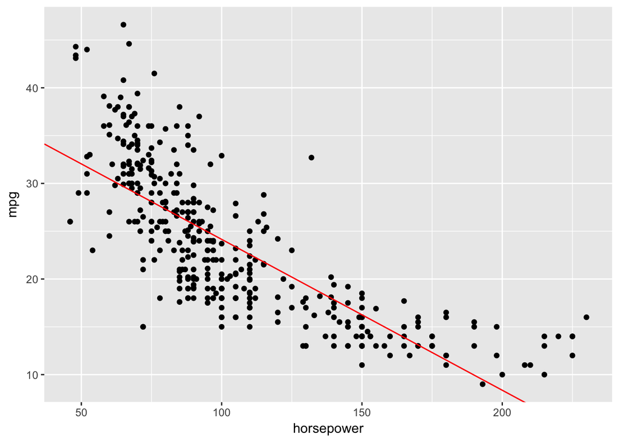

```r
p <- ggplot(Auto) +
  geom_point(aes(horsepower, mpg)) +
  geom_abline(aes(intercept = coef(lm08)[1], slope = coef(lm08)[2]), col = 'red')
p
```